# Elevation Vignette

Erik W. Leppo

2019-01-24

# Background

Arizona splits their sites into high and low elevation (5,000 ft). There is a different multi-metric index for each classification. So it is important to have the correct elevation and thus MMI. Not all AZ sites in the data set had elevation data. The only way to get the elevation category is to read the two separate reach files. But some sites are in both files.

Could obtain in GIS with a DEM but more efficient to keep in R. The function (getElev) in `CASTfxn` package is used obtain elevation from USGS Elevation Point Query Services (EPQS). This is done through the `elevatr` package.

# AZ data

A large portion of the AZ Station data was missing elevation data so had to rely on whether the sites were in each of the reach files (high and low elevation).

```r
# Packages
library(CASTfxn)
#
# Data
df_AZ <- data_Sites
#
# Summarize
cnt.NA <- sum(is.na(df_AZ$Elevation))
cnt.Total <- nrow(df_AZ)
pct.NA  <- round(cnt.NA / cnt.Total, 3)
#
summary(df_AZ$Elevation)
```

```
##    Min. 1st Qu.  Median    Mean 3rd Qu.    Max.    NA's
##     764    3175    4172    4684    6160    9580    1692
```

```r
knitr::kable(cbind(cnt.NA, cnt.Total, pct.NA), caption = "Missing Data for AZ Stations Elevation")
```

Missing Data for AZ Stations Elevation

| cnt.NA | cnt.Total | pct.NA |
| --- | --- | --- |
| 1692 | 2244 | 0.754 |

# Get Elevation

Use the new getElev() function in CASTfxn to obtain elevation data for all sites.

This takes about 10 minutes for all 2,244 sites.

```r
# Packages
library(CASTfxn)
# Function Arguments
df_loc <- data_Sites
Lat <- "FinalLatitude"
Long <- "FinalLongitude"
elev_units <- "feet"
proj_loc <- "+proj=longlat +ellps=WGS84 +datum=WGS84 +no_defs"
# Run Function
df_elev <- getElev(df_loc, Lat, Long, elev_units, proj_loc)
# Save Results
dir_out <- getwd()
fn_out <- file.path(dir_out, "AZ_Elev.tsv")
write.table(df_elev, fn_out, sep="\t", row.names=FALSE, col.names = TRUE)
```

# Append Elevation

Use saved file.

```r
# Packages
library(CASTfxn)
library(ggplot2)

# Data
dir_data <- file.path(path.package(package="CASTfxn"), "extdata")
fn_elev <- file.path(dir_data, "AZ_Elev.tsv")
df_elev <- read.delim(fn_elev)
# new class elevation category
df_elev$ElevCat2 <- ifelse(df_elev$elevation>=5000,"hi","lo")

# Table
knitr::kable(table(df_elev$ElevCategory, df_elev$ElevCat2), caption="Elevation Categories (Left=AZ, Top=getElev)")
```

Elevation Categories (Left=AZ, Top=getElev)

|  | hi | lo |
| --- | --- | --- |
| HI | 795 | 76 |
| LO | 0 | 1373 |

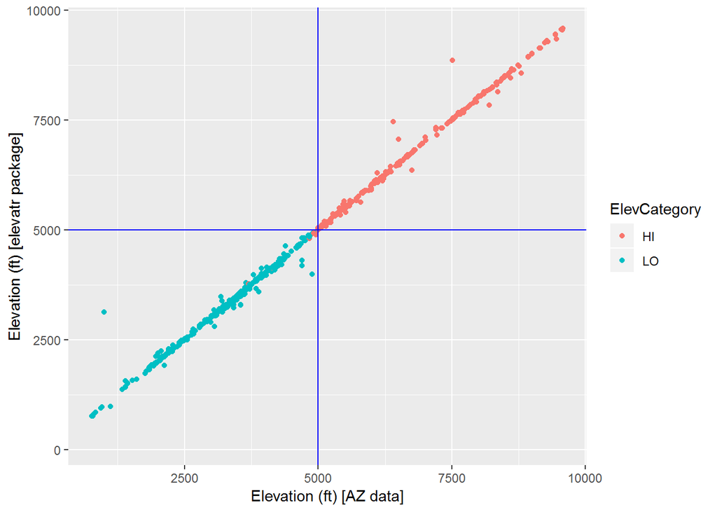

```r
# Plot 1, Elevation Category
p1 <- ggplot(df_elev, aes(Elevation, elevation, color=ElevCategory)) +
  geom_point() +
  geom_hline(yintercept=5000, color="blue") +
  geom_vline(xintercept=5000, color="blue") +
  labs(x="Elevation (ft) [AZ data]", y="Elevation (ft) [elevatr package]")
p1
```

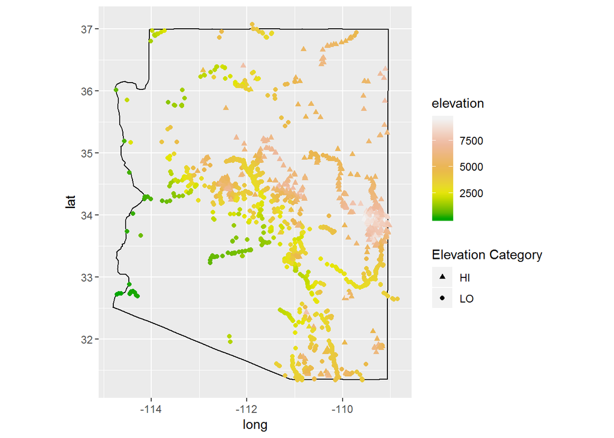

```r
# Plot 2, State Map
p3 <- ggplot(data = subset(map_data("state"), region =="arizona")) +
  geom_polygon(aes(x=long, y=lat, group=group), fill=NA, color="black") +
  coord_fixed(1.3) +
  geom_point(data=df_elev, aes(FinalLongitude, FinalLatitude, color=elevation, shape=ElevCategory)) +
  scale_shape_manual(name="Elevation Category", values=c(17,16)) +
    scale_color_gradientn(colours = terrain.colors(5))
p3
```

# Raster

It is possible to use the `elevatr` package with a raster DEM (e.g., NED snapshot from NHD+ v2). The `FedData` package can get raster NED. However, the query method above is quicker.